# Stat 184 Final

Cassandra Pomarico

*Source file* ⇒ Stat_184_Final.Rmd

I am conducting research to see what kind of people tend to vote. My goal is to see if particular characteristics of a person leads them to have a certain voter outcome. I will be studying the relationship of these variables through the 2016 ANES dataset, otherwise known as the American National Election Studies in the recent Trump-Clinton election.

```r
library(DataComputing)
setwd("~/Desktop/PLSC 309")
anes2016 <- read.csv("anes2016.csv")
anes2016 %>% head(10)
```

```
##    caseid weight_full mode voted2012 regist2016 primary2016 intend.vote
## 1  300001      0.8420    1         0          1           0           1
## 2  300002      1.0133    1         1          1           0           1
## 3  300003      0.3672    1         0          0           0          NA
## 4  300004      0.3663    1         1          1           0          NA
## 5  300006      0.6463    1         1          1           0           1
## 6  300007      0.6881    1         1          1           0          NA
## 7  300008      4.6151    1         1          1           1           1
## 8  300012      0.9426    1         1          1           1           1
## 9  300018      1.0097    1         1          0           0          NA
## 10 300020      0.6005    1         0          1           0          NA
##    ideology pid_strength born_again fundamentalist race female income
## 1        NA            7          1              0    1      0      3
## 2         5            6          0              0    1      0      4
## 3        NA            3          0              0    1      0      1
```

[output cut: 150 more lines]

```r
summary(anes2016)
```

```
##      caseid        weight_full          mode         voted2012
##  Min.   :300001   Min.   :0.0000   Min.   :1.000   Min.   :0.0000
##  1st Qu.:302603   1st Qu.:0.3934   1st Qu.:1.000   1st Qu.:0.0000
##  Median :402420   Median :0.7481   Median :2.000   Median :1.0000
##  Mean   :375574   Mean   :0.8544   Mean   :1.723   Mean   :0.7326
##  3rd Qu.:405090   3rd Qu.:1.1297   3rd Qu.:2.000   3rd Qu.:1.0000
##  Max.   :407800   Max.   :6.4445   Max.   :2.000   Max.   :1.0000
##                                                    NA's   :16
##    regist2016      primary2016      intend.vote        ideology
##  Min.   :0.0000   Min.   :0.0000   Min.   :0.0000   Min.   :1.000
##  1st Qu.:1.0000   1st Qu.:0.0000   1st Qu.:1.0000   1st Qu.:3.000
##  Median :1.0000   Median :0.0000   Median :1.0000   Median :4.000
##  Mean   :0.8578   Mean   :0.4413   Mean   :0.9404   Mean   :4.176
##  3rd Qu.:1.0000   3rd Qu.:1.0000   3rd Qu.:1.0000   3rd Qu.:6.000
##  Max.   :1.0000   Max.   :1.0000   Max.   :1.0000   Max.   :7.000
##  NA's   :8        NA's   :6        NA's   :566      NA's   :967
##   pid_strength      born_again     fundamentalist         race
##  Min.   :-9.000   Min.   :0.0000   Min.   :0.00000   Min.   :1.000
##  1st Qu.: 2.000   1st Qu.:0.0000   1st Qu.:0.00000   1st Qu.:1.000
##  Median : 4.000   Median :0.0000   Median :0.00000   Median :1.000
##  Mean   : 3.822   Mean   :0.3184   Mean   :0.03201   Mean   :1.816
##  3rd Qu.: 6.000   3rd Qu.:1.0000   3rd Qu.:0.00000   3rd Qu.:2.000
##  Max.   : 7.000   Max.   :1.0000   Max.   :1.00000   Max.   :6.000
##  NA's   :11                        NA's   :54        NA's   :33
##      female          income        hannity         minutes60
##  Min.   :0.000   Min.   :1.00   Min.   :0.0000   Min.   :0.000
##  1st Qu.:0.000   1st Qu.:2.00   1st Qu.:0.0000   1st Qu.:0.000
##  Median :1.000   Median :3.00   Median :0.0000   Median :0.000
##  Mean   :0.529   Mean   :3.31   Mean   :0.1051   Mean   :0.307
##  3rd Qu.:1.000   3rd Qu.:5.00   3rd Qu.:0.0000   3rd Qu.:1.000
##  Max.   :1.000   Max.   :6.00   Max.   :1.0000   Max.   :1.000
##  NA's   :52      NA's   :202    NA's   :541      NA's   :541
##      cooper          matthews          press            conan
##  Min.   :0.0000   Min.   :0.0000   Min.   :0.0000   Min.   :0.0000
##  1st Qu.:0.0000   1st Qu.:0.0000   1st Qu.:0.0000   1st Qu.:0.0000
##  Median :0.0000   Median :0.0000   Median :0.0000   Median :0.0000
##  Mean   :0.1504   Mean   :0.0735   Mean   :0.1244   Mean   :0.0424
##  3rd Qu.:0.0000   3rd Qu.:0.0000   3rd Qu.:0.0000   3rd Qu.:0.0000
##  Max.   :1.0000   Max.   :1.0000   Max.   :1.0000   Max.   :1.0000
##  NA's   :541      NA's   :541      NA's   :541      NA's   :541
```

[output cut: 137 more lines]

```
##  Min.   :0.0000   Min.   :0.0000   Min.   :0.0000   Min.   :0.0000
##  1st Qu.:0.0000   1st Qu.:0.0000   1st Qu.:0.0000   1st Qu.:0.0000
##  Median :1.0000   Median :0.0000   Median :1.0000   Median :0.0000
##  Mean   :0.5658   Mean   :0.4152   Mean   :0.6394   Mean   :0.2758
##  3rd Qu.:1.0000   3rd Qu.:1.0000   3rd Qu.:1.0000   3rd Qu.:1.0000
##  Max.   :1.0000   Max.   :1.0000   Max.   :1.0000   Max.   :1.0000
##  NA's   :1217     NA's   :1217
##    Clinton16
##  Min.   :0.000
##  1st Qu.:0.000
##  Median :0.000
##  Mean   :0.302
##  3rd Qu.:1.000
##  Max.   :1.000
##
```

```r
names(anes2016)
```

```
##  [1] "caseid"              "weight_full"         "mode"
##  [4] "voted2012"           "regist2016"          "primary2016"
##  [7] "intend.vote"         "ideology"            "pid_strength"
## [10] "born_again"          "fundamentalist"      "race"
## [13] "female"              "income"              "hannity"
## [16] "minutes60"           "cooper"              "matthews"
## [19] "press"               "conan"               "big.bang"
## [22] "modern.family"       "rush"                "NPR"
## [25] "voted2016"           "vote.choice2016"     "Dem.Pres.candFT"
## [28] "GOP.Pres.candFT"     "Lib.Pres.candFT"     "Green.Pres.candFT"
## [31] "Dem.House.candFT"    "GOP.House.candFT"    "Ind.House.candFT"
## [34] "Dem.Sen.candFT"      "GOP.Sen.candFT"      "Ind.Sen.candFT"
## [37] "Sr.SenFT"            "Jr.SenFT"            "Nonrun.SenFT"
## [40] "Dem.VP.candFT"       "GOP.VP.candFT"       "RobertsFT"
## [43] "PopeFT"              "Christian.FundFT"    "FemFT"
```

[output cut: 16 more lines]

In the above r section I have read in my csv dataset. I also gathered the variable names which I have found there is 93 different variables and took 10 rows of data.

```r
anes2016 %>%
 group_by(female ) %>%
  summarise(count=n())
```

```
## # A tibble: 3 x 2
##   female count
##    <int> <int>
## 1      0  1987
## 2      1  2232
## 3     NA    52
```

```r
anes2016 %>%
  group_by(employed) %>%
  summarise(count=n())
```

```
## # A tibble: 2 x 2
##   employed count
##      <int> <int>
## 1        0  1648
## 2        1  2623
```

Above I have used data wrangling to create data tables to see what the majority of voters are like. As you can see more of the voters in the 2016 election were in fact females. Above you can also see the data table that shows employment, more participants in the 2016 election were employed.

### Does Gender Effect Which Canidate a Person Votes For?

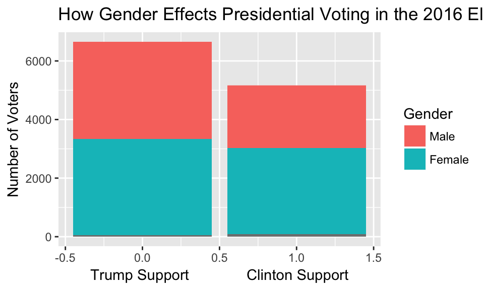

```r
library(ggplot2)
anes2016 %>%
  ggplot(aes(x=Clinton16, y=voted2016,fill=factor(female))) +
  geom_bar(stat = "identity", position = "stack")+
  scale_fill_discrete(name="Gender",
                         breaks=c("0", "1"),
                         labels=c("Male", "Female")) +
  ggtitle("How Gender Effects Presidential Voting in the 2016 Election")+
  xlab("Trump Support              Clinton Support")+
  ylab("Number of Voters")
```

Above I have created a graph that shows the relationship between gender, presidential prefrence, and number of votes in the election. As you can see more females and males voted for Trump during the 2016 election. I can conclude that both more females voted for Trump than Clinton although the data was almost equal. For males there was a significant difference between men voting for Trump versus Clinton.

### Does Education Levels Effect Voter Turnout?

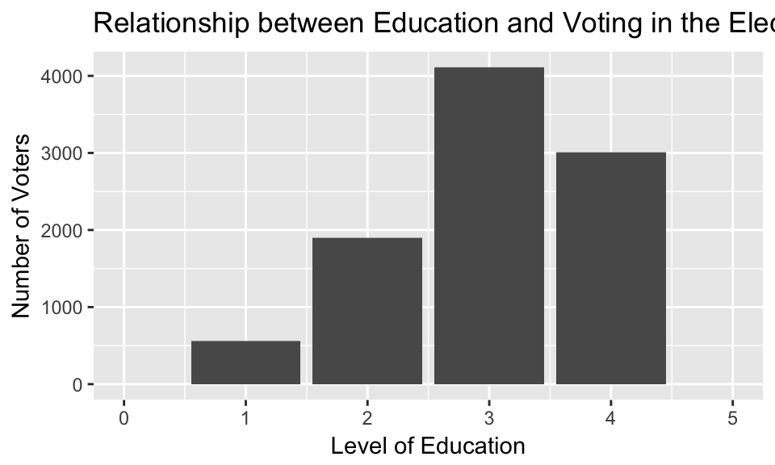

```r
anes2016 %>%
  ggplot(aes(x=educ, y=voted2016)) +
  geom_bar(stat = "identity", position = "stack")+
  ggtitle("Relationship between Education and Voting in the Election")+
  xlab("Level of Education")+
  ylab("Number of Voters")+
  scale_x_continuous(limits =c(0,5))
```

The graph above shows the relationship between education and voting in the 2016 election. As you can see when the level of education was at 3 which refers to completing 4 years of college with a dimpolma, the voter turnout was the highest.

### Do Certain States Have Higher Voter Outcomes than Others?

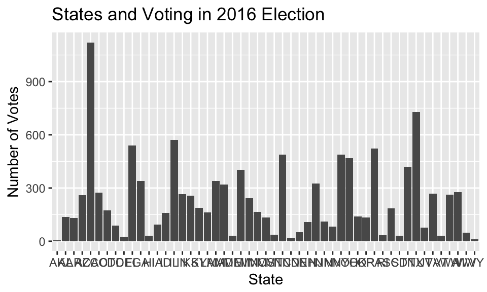

```r
anes2016 %>%
  ggplot(aes(x=location, y=voted2016)) +
  geom_bar(stat = "identity")+
  ggtitle("States and Voting in 2016 Election")+
  xlab("State") +
  ylab("Number of Votes")
```

Above shows the relationship between states and voting in the election. As you can see California has the highest voter tunrout.

### Does Gender Skew Your Political Party a Certain Way?

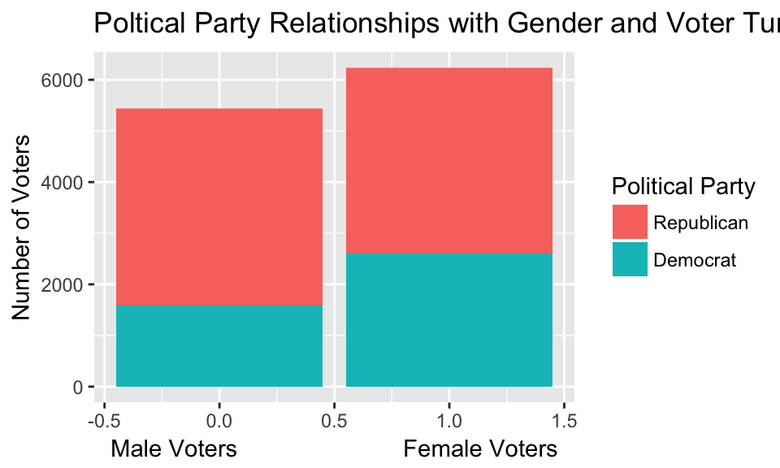

```r
library(ggplot2)
anes2016 %>%
  ggplot(aes(x=female, y=voted2016,fill=factor(Dem))) +
  geom_bar(stat = "identity", position = "stack")+
  scale_fill_discrete(name="Political Party",
                         breaks=c("0", "1"),
                         labels=c("Republican", "Democrat")) +
  ggtitle("Poltical Party Relationships with Gender and Voter Turnout")+
  xlab("Male Voters                         Female Voters")+
  ylab("Number of Voters")
```

Overall I displayed several relationships between different variables and if they effected the way people voted by using several displays of graphs.